# Reproducible Research: Peer Assessment 1

Michael F Totoraitis

September 12, 2019

## Loading and preprocessing the data

First step is to load and process the data.

```r
library(dplyr)
library(readr)

#1 Code for reading in the dataset and processing it
d <- read_csv("activity.csv", col_types = cols(steps = col_number()),
              na = "NA")

d1 <- d %>%
      group_by(date) %>%
      summarize(
            total_steps = sum(steps, na.rm = T),
            mean_int_steps = mean(steps, na.rm=T),
            median_int_steps = median(steps, na.rm=T))
```

## What is mean total number of steps taken per day?

Examine a histogram of the total number of steps taken each day.

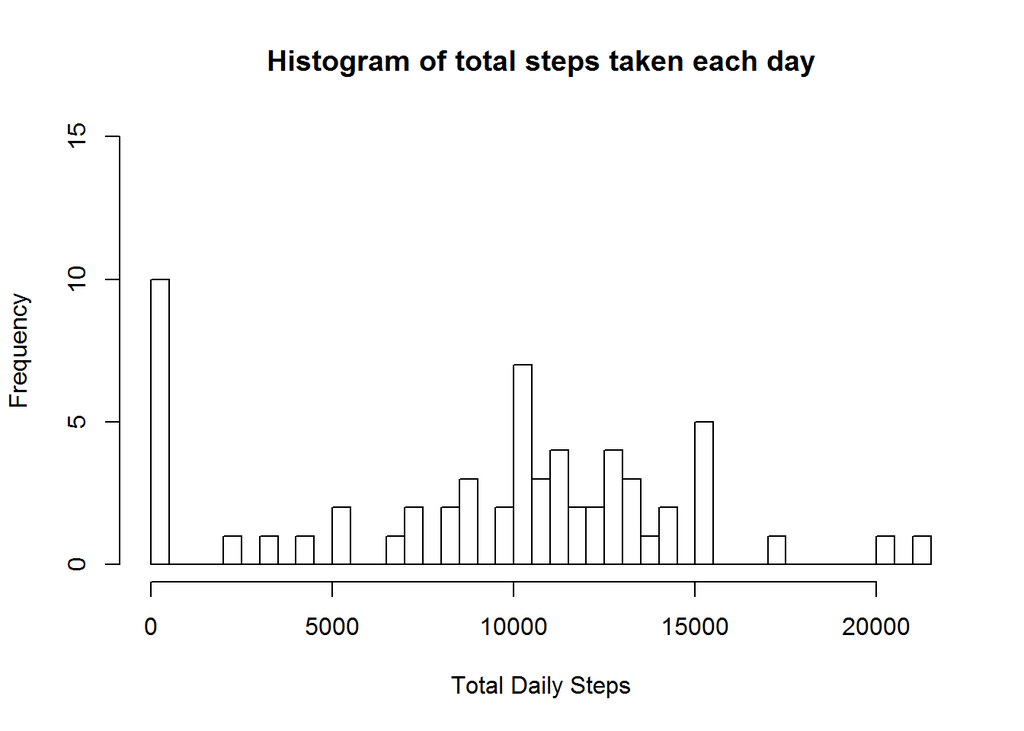

```r
hist(d1$total_steps, breaks = 61, ylim=c(0,15),
     xlab = "Total Daily Steps", main = "Histogram of total steps taken each day")
```

Calculate the mean and median total number of steps taken per day.

```r
mean(d1$total_steps, na.rm = T)
```

```
## [1] 9354.23
```

```r
median(d1$total_steps, na.rm = T)
```

```
## [1] 10395
```

## What is the average daily activity pattern?

Create a time series plot to examine the average daily activity pattern.

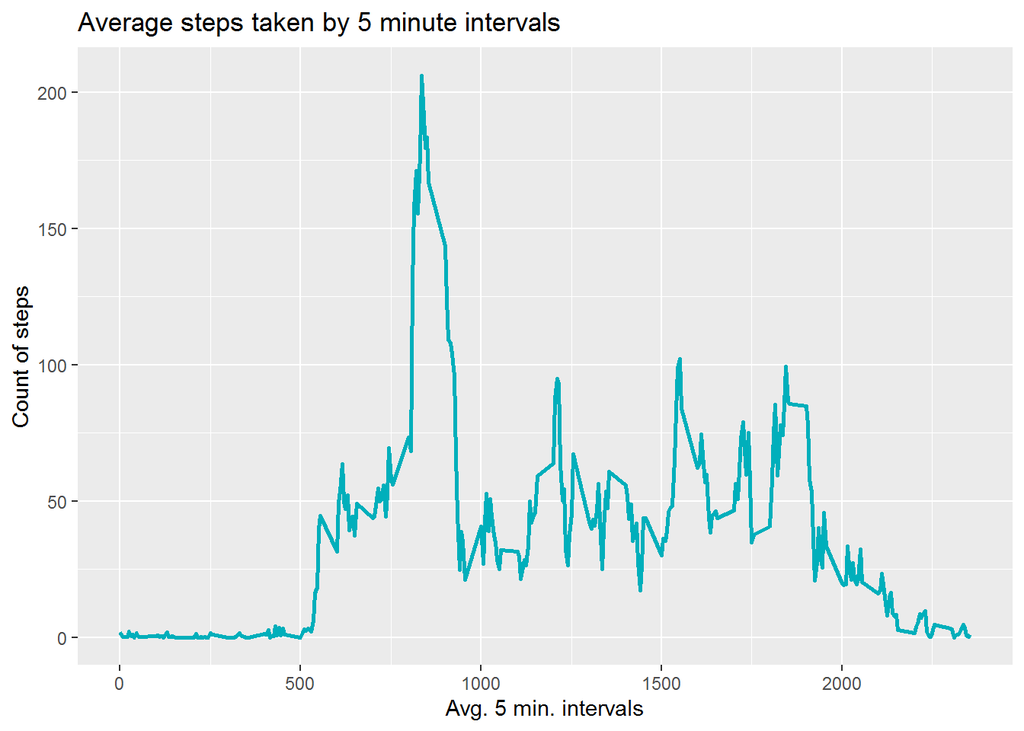

```r
library(ggplot2)

d2 <- d %>%
      group_by(interval) %>%
      summarize(
            mean_int_steps = mean(steps, na.rm=T))

ggplot(d2)+ geom_line(aes(interval,mean_int_steps),color = "#00AFBB", size = 1) +
      labs(
            title = paste("Average steps taken by 5 minute intervals"),
            x = paste("Avg. 5 min. intervals"),
            y = paste("Count of steps"))
```

Examine the 5-minute interval that, on average, contains the maximum number of steps.

```r
max(d2$mean_int_steps, na.rm = T)
```

```
## [1] 206.1698
```

```r
filter(d2,mean_int_steps>=206.1698)
```

```
## # A tibble: 1 x 2
##   interval mean_int_steps
##      <dbl>          <dbl>
## 1      835           206.
```

## Imputing missing values

First determine the number of missing steps values.

```r
sum(is.na(d$steps))
```

```
## [1] 2304
```

Imput the mean of the overall steps into a new dataset.

```r
d_imputed <- d
d_imputed$steps[is.na(d_imputed$steps)] = mean(d_imputed$steps, na.rm=TRUE)
```

Examine the histogram of the total number of steps taken each day after the missing values have been imputed

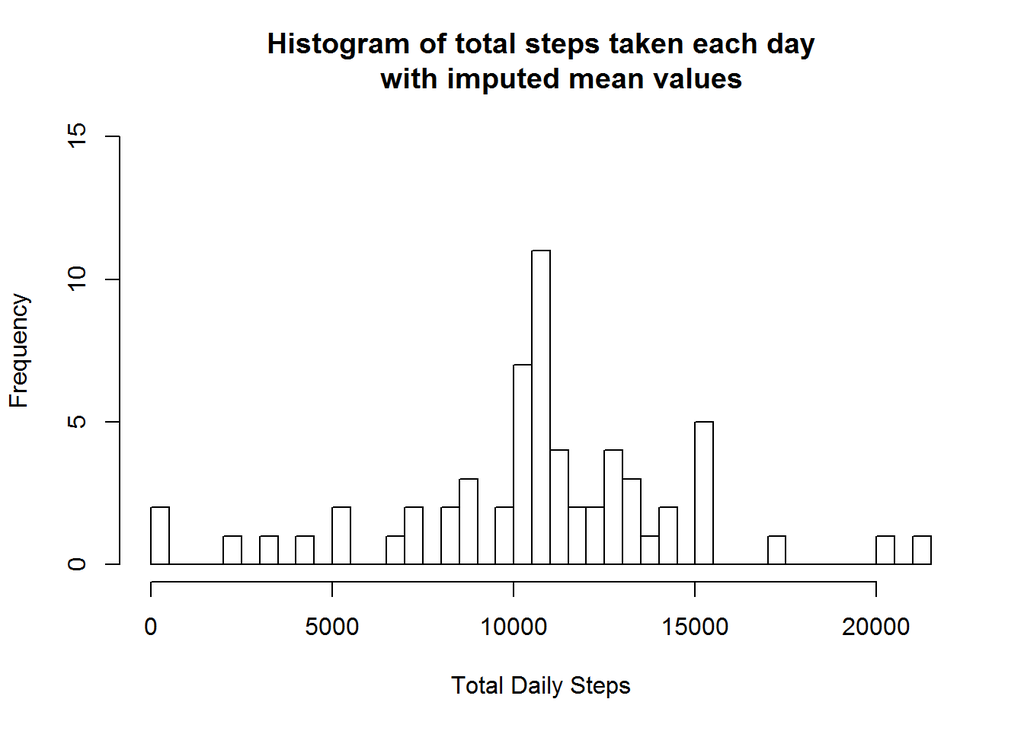

```r
d2_imputed <- d_imputed %>%
      group_by(date) %>%
      summarize(
            total_steps = sum(steps))

hist(d2_imputed$total_steps, breaks = 61, ylim=c(0,15),
     xlab = "Total Daily Steps", main = "Histogram of total steps taken each day
     with imputed mean values")
```

Examine the mean and median’s of the new dataset with imputed values.

```r
mean(d2_imputed$total_steps)
```

```
## [1] 10766.19
```

```r
median(d2_imputed$total_steps)
```

```
## [1] 10766.19
```

The values generated from imputed missing values does differ from the first part of the assignment. The imputed missing values increases both the mean and median values calculated.

## Are there differences in activity patterns between weekdays and weekends?

To examine the differences between weekdays and weekends, first code in a new variable for the whether or not the value is a weekday or a weekend.

```r
d_imputed$day <- '0'
d_imputed$day <- weekdays(d_imputed$date)
d_imputed$day_type <- '0'
d_imputed$day_type[d_imputed$day == "Monday" | d_imputed$day == "Tuesday" |
            d_imputed$day=="Wednesday" | d_imputed$day=="Thursday" |
            d_imputed$day=="Friday"] <- '1'
d_imputed$day_type[d_imputed$day == "Saturday" | d_imputed$day == "Sunday"] <- '2'

imputed <- d_imputed %>%
      group_by(interval,day_type) %>%
      summarize(
            mean_int_steps = mean(steps, na.rm=T))
```

Then plot the line graph by the type of day to examine the differences.

[figure not shown]

```r
imputed$day_type <- factor(imputed$day_type, labels = c("Weekend","Weekday"))

ggplot(imputed)+ geom_line(aes(interval,mean_int_steps, color = day_type)
                           , size = 1) +
      labs(
            title = paste("Average steps taken by 5 minute intervals"),
            subtitle = paste("Calculated with imputed mean steps"),
            x = paste("Avg. 5 min. intervals"),
            y = paste("Count of steps")) +
     facet_wrap(~day_type, ncol = 1, labeller = label_both)
```